# Table of Contents

```python
%config Completer.use_jedi = False
```

```python
from IPython.display import Image
```

# **Interesting Resources**

- Repeating Python Lessons(Data Camp)

http://localhost:8888/notebooks/Data%20Science-Ariel%20%2C%20Data%20Camp%20%2C%20DSDJ/Cheatsheet/Repeating%20Notion%20Courses.ipynb#Parallel-Programming-with-Dask-in-Python

- Corey Schafer's - Python Tutorial

http://localhost:8888/notebooks/Data%20Science-Ariel%20%2C%20Data%20Camp%20%2C%20DSDJ/Cheatsheet/Python%20Cheatsheet%20-%20Corey%20Schafer.ipynb

# **Python Introduction - W3schools**

## What is Python?

Python is a popular programming language. It was created by Guido van Rossum, and released in 1991.

### It is used for:

```
web development (server-side),
software development,
mathematics,
system scripting.
```

### What can Python do?

```
Python can be used on a server to create web applications.
Python can be used alongside software to create workflows.
Python can connect to database systems. It can also read and modify files.
Python can be used to handle big data and perform complex mathematics.
Python can be used for rapid prototyping, or for production-ready software development.
```

### Why Python?

```
Python works on different platforms (Windows, Mac, Linux, Raspberry Pi, etc).
Python has a simple syntax similar to the English language.
Python has syntax that allows developers to write programs with fewer lines than some other programming languages.
Python runs on an interpreter system, meaning that code can be executed as soon as it is written. This means that prototyping can be very quick.
Python can be treated in a procedural way, an object-oriented way or a functional way.
```

### Good to know

```
The most recent major version of Python is Python 3, which we shall be using in this tutorial. However, Python 2, although not being updated with anything other than security updates, is still quite popular.
In this tutorial Python will be written in a text editor. It is possible to write Python in an Integrated Development Environment, such as Thonny, Pycharm, Netbeans or Eclipse which are particularly useful when managing larger collections of Python files.
```

### Python Syntax compared to other programming languages

```
Python was designed for readability, and has some similarities to the English language with influence from mathematics.
Python uses new lines to complete a command, as opposed to other programming languages which often use semicolons or parentheses.
Python relies on indentation, using whitespace, to define scope; such as the scope of loops, functions and classes. Other programming languages often use curly-brackets for this purpose.
```

# **General Python-Bash Commands**

- Check Python Version

```python
!python3 --version
```

```
Python 3.10.6
```

- Check pip version and location

```python
!pip -V
```

```
pip 21.2.4 from C:\Users\UserPc\anaconda3\lib\site-packages\pip (python 3.9)
```

- Create a virtual Environment

```python
!python3 -m venv NameOfProject
```

# **W3schools**

## Python Variables

```python
# Many Values to Multiple Variables
x, y, z = 'Orange', 'Banana', 'Cherry'
```

```python
x
```

```
'Orange'
```

```python
# One Value to Multiple Variables
x = y = z = 'Orange'
```

```python
x
```

```
'Orange'
```

```python
# Unpack a Collection
fruits = ['apple', 'banana', 'cherry']
x, y, z = fruits
```

```python
x
```

```
'apple'
```

### Global Variables

- Global variables are variables that are created outside of a function. They can be used anywhere in the scripts

```python
x = 'This is a global variable'

def myfunc():
    print(x)

myfunc()
```

```
This is a global variable
```

- Compared to that, a local variable is a variable that is created locally, and can only be used there

```python
x = 'This is a global variable'

def myfunc():
    y = 'This is a local variable'
    print(x)
    print(y)

myfunc()
```

```
This is a global variable
This is a local variable
```

```python
# Using the local variable outside of the function will return an error
print(y)
```

[output not shown]

- We can create a variable locally and tell python to use it globally using the global keyword

```python
def myfunc():
    x = 'This is a local variable'
    print(x)

myfunc()
```

```
This is a local variable
```

```python
def myfunc():
    global x
    x = 'This is a local AND global variable'
    print(x)

myfunc()
print(x)
```

```
This is a local AND global variable
This is a local AND global variable
```

## Operators

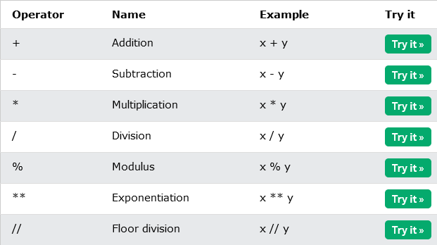

```python
Image('Arithmetic Operators.png')
```

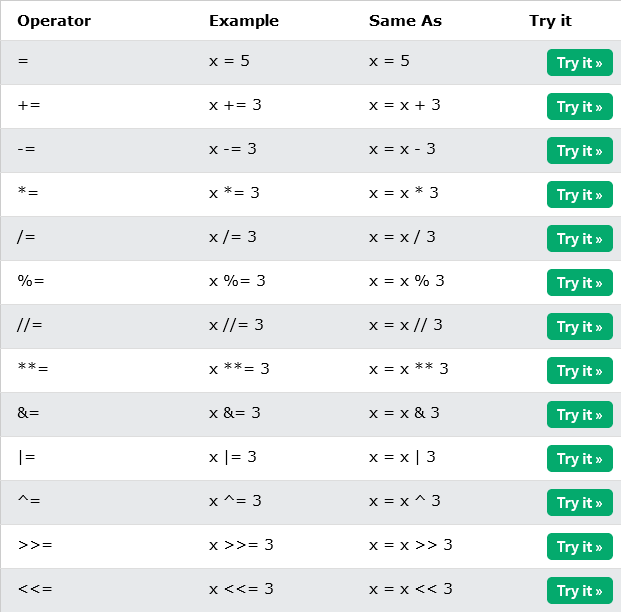

```python
Image('Assignment Operators.png')
```

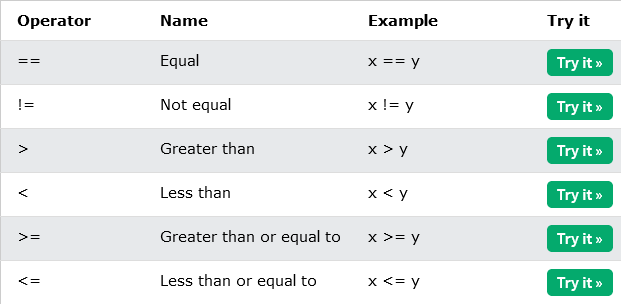

```python
Image('Comparison Operators.png')
```

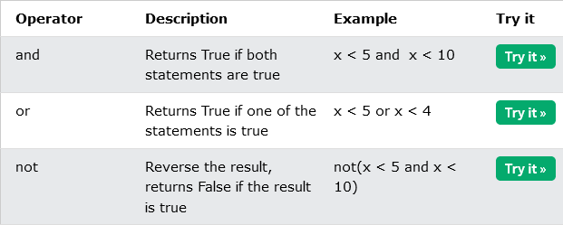

```python
Image('Logical Operators.png')
```

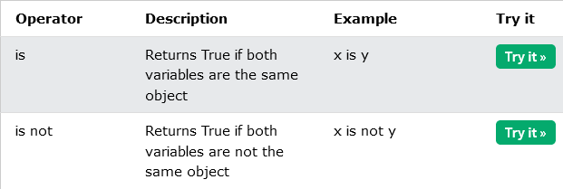

```python
Image('Identity Operators.png')
```

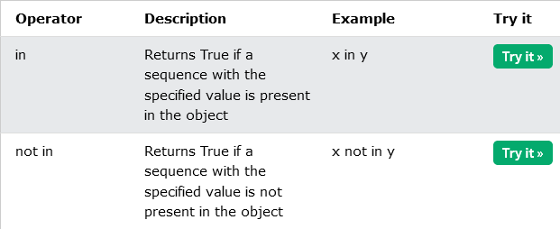

```python
Image('Membership Operators.png')
```

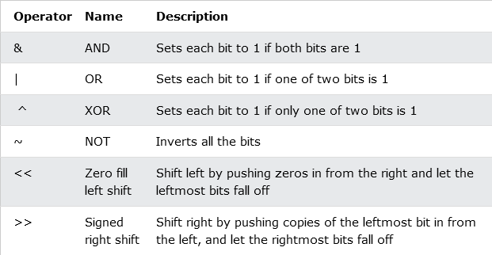

```python
Image('Bitwise Operators.png')
```

```python
## Python Collections (Arrays)
```

There are four collection data types in the Python programming language:

```
- List is a collection which is ordered and changeable. Allows duplicate members.
- Tuple is a collection which is ordered and unchangeable. Allows duplicate members.
- Set is a collection which is unordered, unchangeable*, and unindexed. No duplicate members.
- Dictionary is a collection which is ordered** and changeable. No duplicate members.
```

## While loops

```python
# The break Statement
i = 1
while i < 6:
  print(i)
  if i == 3:
    break
  i += 1
```

```
1
2
3
```

```python
# The continue Statement
i = 0
while i < 6:
  i += 1
  if i == 3:
    continue
  print(i)
```

```
1
2
4
5
6
```

```python
# The else Statement
i = 1
while i < 6:
  print(i)
  i += 1
else:
  print("i is no longer less than 6")
```

```
1
2
3
4
5
i is no longer less than 6
```

## Functions

### Arbitrary Arguments, *args

- If you do not know how many arguments that will be passed into your function, add a * before the parameter name in the function definition.
- This way the function will receive a tuple of arguments, and can access the items accordingly:

```python
def print_the_second_name(*names):
    print(names[1])
```

```python
print_the_second_name('Yuval', 'Bar', 'Dekel')
```

```
Bar
```

### Arbitrary Keyword Arguments, **kwargs

- If you do not know how many keyword arguments that will be passed into your function, add two asterisk: ** before the parameter name in the function definition.
- This way the function will receive a dictionary of arguments, and can access the items accordingly:

```python
def my_function(**kid):
    print("His last name is " + kid["lname"])

my_function(fname = "Tobias", lname = "Refsnes")
```

```
His last name is Refsnes
```